# Clasificación usando Naive Bayes

# 1. Introducción

- Vimos que el algoritmo Naive Bayes clasifica de manera probabilística
- La probabilidad de que un objeto pertenezca a cierta clase depende de las características que tenga
- Por medio del cálculo de probabilidades posteriores en función de los datos de entrenamiento que se tengan
- Para filtrar correos spam, por ejemplo, las palabras contenidas en el correo determinan el nivel al que pertenece
- Esto en función de la frecuencia de dichas palabras en correos spam previamente clasificados
- Aplicaremos esta técnica para asignar legisladores a un partido en función de su comportamiento legislativo

# 2. Predicción del partido político de legisladores en EEUU

- En el siguiente ejemplo usaremos el algoritmo Naive Bayes para predecir el partido político de los legisladores
- Tenemos información sobre representantes a la Cámara en EEUU
- La base `votos84.csv` contiene información sobre un conjunto de representantes a la Cámara en EEUU en 1984
- También contiene información sobre cómo votaron (Sí o No) por un conjunto de 16 propocisiones durante su legislatura
- La idea es mostrar cómo el comportamiento legislativo permite determinar la ideología, y por ende, el partido de estos congresistas

# 3. Datos

- Leamos los datos como un data frame

```r
votos84 <- read.csv("votos84.csv")
```

- Veamos la estrucutra de los datos

```r
str(votos84)
```

```
'data.frame':   435 obs. of  17 variables:
 $ Class: Factor w/ 2 levels "democrat","republican": 2 2 1 1 1 1 1 2 2 1 ...
 $ V1   : Factor w/ 2 levels "n","y": 1 1 2 1 2 1 1 1 1 2 ...
 $ V2   : Factor w/ 2 levels "n","y": 2 2 2 2 2 2 2 2 2 2 ...
 $ V3   : Factor w/ 2 levels "n","y": 1 1 2 2 2 2 1 1 1 2 ...
 $ V4   : Factor w/ 2 levels "n","y": 2 2 2 1 1 1 2 2 2 1 ...
 $ V5   : Factor w/ 2 levels "n","y": 2 2 2 1 2 2 2 2 2 1 ...
 $ V6   : Factor w/ 2 levels "n","y": 2 2 2 2 2 2 2 2 2 1 ...
 $ V7   : Factor w/ 2 levels "n","y": 1 1 1 1 1 1 1 1 1 2 ...
 $ V8   : Factor w/ 2 levels "n","y": 1 1 1 1 1 1 1 1 1 2 ...
 $ V9   : Factor w/ 2 levels "n","y": 1 1 1 1 1 1 1 1 1 2 ...
 $ V10  : Factor w/ 2 levels "n","y": 2 1 1 1 1 1 1 1 1 1 ...
 $ V11  : Factor w/ 2 levels "n","y": 1 1 2 2 2 1 1 1 1 1 ...
 $ V12  : Factor w/ 2 levels "n","y": 2 2 1 1 1 1 1 1 2 1 ...
 $ V13  : Factor w/ 2 levels "n","y": 2 2 2 2 2 2 1 2 2 1 ...
 $ V14  : Factor w/ 2 levels "n","y": 2 2 2 1 2 2 2 2 2 1 ...
 $ V15  : Factor w/ 2 levels "n","y": 1 1 1 1 2 2 2 2 1 2 ...
 $ V16  : Factor w/ 2 levels "n","y": 2 1 1 2 2 2 2 2 2 1 ...
```

- Grafiquemos la proporción de votos por el asunto 1 para el total de legisladores

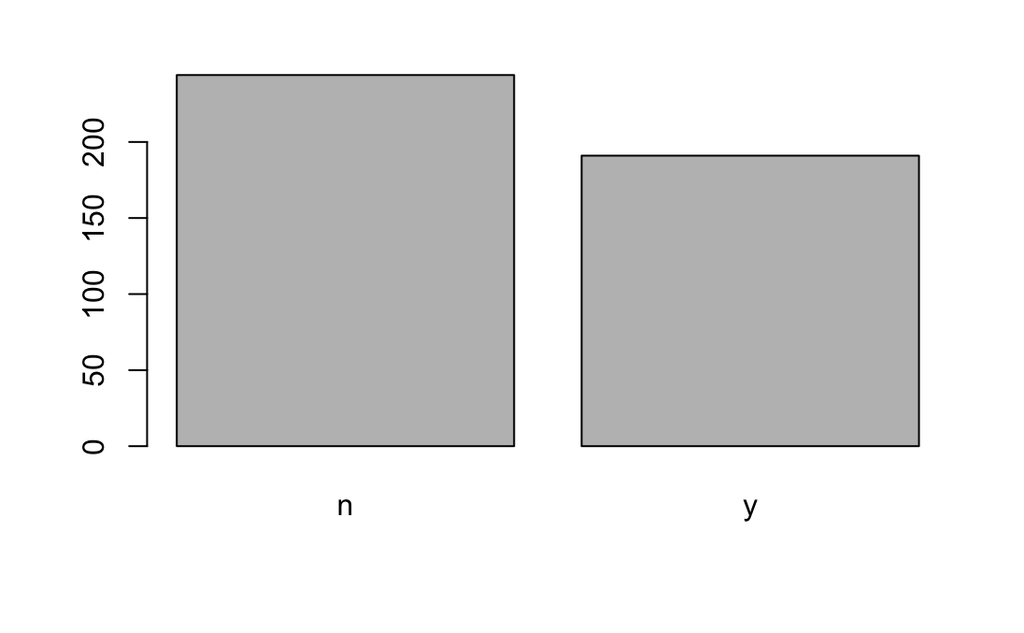

```r
plot(as.factor(votos84[,2]))
```

- Ahora lo mismo para legisladores republicanos

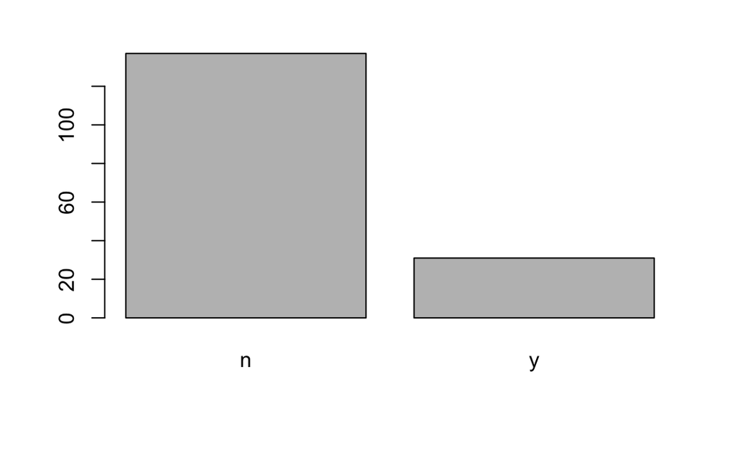

```r
plot(as.factor(votos84[votos84$Class=='republican',2]))
```

- Y ahora para los demócratas

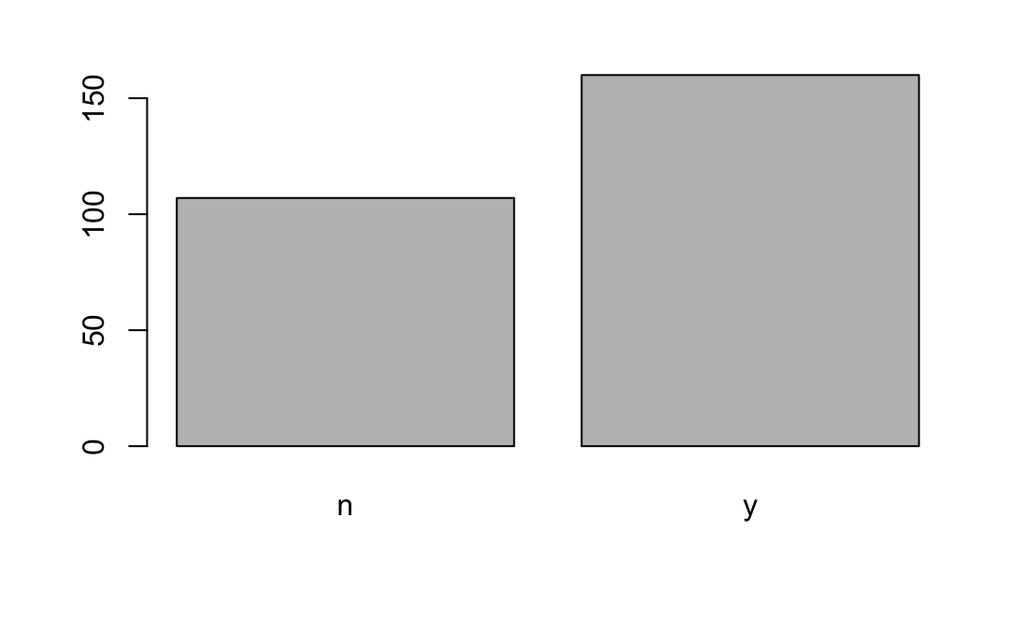

```r
plot(as.factor(votos84[votos84$Class=='democrat',2]))
```

- Claramente se ven diferencias en el comportamiento legislativo entre miembros de un partido y del otro
- Estas son las diferencias que explotaremos

# 4. Preparación de los datos

- Dividiremos la base de datos en dos: 335 observaciones para entrenar el modelo y las restantes 100 para probarlo
- Hacemos esta división de manera aleatoria
- Para esto creamos un vector de 335 números que pueden tomar cualquier valor entre 1 y 435.
- Esos número serán las observaciones que formarán parte del conjunto de entrenamiento
- El resto serán las del conjunto de prueba
- Fijemos primero una semilla para poder replicar los resultados después
- Este paso es importante siempre que haya un procedimiento aleatorio de por medio que querramos replicar posteriormente

```r
set.seed(123)
```

- Creemos un vector de 335 números aleatorios entre 1 y 435

```r
train_sample <- sample(435, 335)
```

- Echémosle un vistazo al vector:

```r
train_sample
```

```
  [1] 126 343 178 382 406  20 227 432 236 195 407 193 287 242  44 378 104
 [18]  18 137 398 370 423 265 410 270 291 223 243 118  60 391 365 279 320
 [35]  10 192 303  87 127  92  57 164 163 145 431  55  91 181 103 332 418
 [52] 170 306  47 214  79  49 285 338 141 250  36 144 387 399 166 299 369
 [69] 292 161 276 230 258   1 172  80 417 220 435  40 416 237 148 278  37
 [86] 153 344 311 308  61  46 225 425 349 110  64 266  32 158 361 201 112
[103] 393 317 160 294 301 200 135  48 304  98 430 383 232 345 176 325 186
[120] 128 205 101  97  69 115 322 326  29 421 212 189 271 204 409 157 198
[137] 246 235 367 131 396 121   4  54 368  68  70  23  71 210 422 142 341
[154] 289 377 283 331 346 124 352 139 313 433 102 274 392 328 405 111 414
[171] 167 379 228 196 175 366 318 359 342 149 215 360 180  67 150 330  66
[188] 376 226 222 290 380 240 151 247 334 324 329 351 136 395 241 248 120
[205]  93 203  84 249  39 429 109 298 264 251  11 155  78  90 179 199 404
[222] 206 156 146  12  83 100 117 411 305 397  88 267 211  53 254 356 165
[239]  31 337 107 129  34 122 268 138  76 183 388 427 309  41 257 302 259
[256] 284 197  72 229 350 162 154 208 394  89  99 224  59 293 177 373   2
[273] 202  27 125 434 358  74 333 272 403  22 255  35   9 191 401 424 420
[290] 239 307  15 221 357 426 348 363 300  14 188 106 336 419 187 286  63
[307]  21 134  58 130 182 315 371   7  43 132 209 347  42 119 384 353  17
[324] 244 238 413 386 280 354 321  65  30 381  86 281
```

- Cada número es una fila que integrará el conjunto de entrenamiento
- Creemos las bases de entrenamiento y prueba usando el vector aleatorio que acabamos de crear

```r
votos84_train <- votos84[train_sample, ]
votos84_test <- votos84[-train_sample, ]
```

- Inspeccionemos estas bases

```r
str(votos84_train)
```

```
'data.frame':   335 obs. of  17 variables:
 $ Class: Factor w/ 2 levels "democrat","republican": 2 1 1 1 2 1 1 1 2 1 ...
 $ V1   : Factor w/ 2 levels "n","y": 1 1 1 2 1 2 1 1 1 1 ...
 $ V2   : Factor w/ 2 levels "n","y": 2 2 1 2 1 2 1 1 1 1 ...
 $ V3   : Factor w/ 2 levels "n","y": 1 2 2 2 1 2 2 2 1 2 ...
 $ V4   : Factor w/ 2 levels "n","y": 2 1 1 1 2 1 1 1 2 1 ...
 $ V5   : Factor w/ 2 levels "n","y": 2 2 1 2 2 1 1 1 2 1 ...
 $ V6   : Factor w/ 2 levels "n","y": 2 2 1 2 2 1 2 1 2 2 ...
 $ V7   : Factor w/ 2 levels "n","y": 1 2 2 2 1 2 2 2 1 2 ...
 $ V8   : Factor w/ 2 levels "n","y": 1 1 2 2 1 2 2 2 1 2 ...
 $ V9   : Factor w/ 2 levels "n","y": 1 1 2 2 1 2 2 2 1 2 ...
 $ V10  : Factor w/ 2 levels "n","y": 2 2 2 2 1 1 1 2 2 2 ...
 $ V11  : Factor w/ 2 levels "n","y": 1 2 2 2 1 2 2 1 1 2 ...
 $ V12  : Factor w/ 2 levels "n","y": 2 1 1 1 2 1 1 1 2 1 ...
 $ V13  : Factor w/ 2 levels "n","y": 2 2 1 2 2 1 1 1 1 1 ...
 $ V14  : Factor w/ 2 levels "n","y": 2 1 1 2 2 1 2 1 2 1 ...
 $ V15  : Factor w/ 2 levels "n","y": 1 2 2 1 1 2 2 1 1 2 ...
 $ V16  : Factor w/ 2 levels "n","y": 2 2 2 2 2 2 2 2 2 2 ...
```

```r
str(votos84_test)
```

```
'data.frame':   100 obs. of  17 variables:
 $ Class: Factor w/ 2 levels "democrat","republican": 1 1 1 2 1 2 2 1 1 1 ...
 $ V1   : Factor w/ 2 levels "n","y": 2 2 1 1 1 1 1 2 2 2 ...
 $ V2   : Factor w/ 2 levels "n","y": 2 2 2 2 2 2 2 2 1 1 ...
 $ V3   : Factor w/ 2 levels "n","y": 2 2 2 1 2 1 1 2 2 2 ...
 $ V4   : Factor w/ 2 levels "n","y": 2 1 1 2 1 2 2 1 1 1 ...
 $ V5   : Factor w/ 2 levels "n","y": 2 2 2 2 1 2 2 1 1 1 ...
 $ V6   : Factor w/ 2 levels "n","y": 2 2 2 2 1 2 2 1 1 1 ...
 $ V7   : Factor w/ 2 levels "n","y": 1 1 1 1 2 1 1 2 2 2 ...
 $ V8   : Factor w/ 2 levels "n","y": 1 1 1 1 2 1 1 2 2 2 ...
 $ V9   : Factor w/ 2 levels "n","y": 1 1 1 1 2 1 1 2 2 2 ...
 $ V10  : Factor w/ 2 levels "n","y": 1 1 1 1 1 2 1 1 1 2 ...
 $ V11  : Factor w/ 2 levels "n","y": 2 2 1 1 1 1 1 1 1 1 ...
 $ V12  : Factor w/ 2 levels "n","y": 1 1 1 1 1 2 2 1 1 1 ...
 $ V13  : Factor w/ 2 levels "n","y": 2 2 2 2 2 2 2 1 1 1 ...
 $ V14  : Factor w/ 2 levels "n","y": 2 2 2 2 1 2 2 1 1 1 ...
 $ V15  : Factor w/ 2 levels "n","y": 1 2 2 2 2 1 1 2 2 2 ...
 $ V16  : Factor w/ 2 levels "n","y": 1 2 2 2 2 1 1 2 2 2 ...
```

- Creemos los vectores con los outcomes

```r
votos84_train_labels <- votos84_train$Class
```

```r
votos84_test_labels <- votos84_test$Class
```

- Eliminemos la columna del outcome en las bases de entrenamiento y prueba

```r
votos84_train <- votos84_train[ ,-1]
```

```r
votos84_test <- votos84_test[ ,-1]
```

- Inspeccionemos las bases

```r
str(votos84_train)
```

```
'data.frame':   335 obs. of  16 variables:
 $ V1 : Factor w/ 2 levels "n","y": 1 1 1 2 1 2 1 1 1 1 ...
 $ V2 : Factor w/ 2 levels "n","y": 2 2 1 2 1 2 1 1 1 1 ...
 $ V3 : Factor w/ 2 levels "n","y": 1 2 2 2 1 2 2 2 1 2 ...
 $ V4 : Factor w/ 2 levels "n","y": 2 1 1 1 2 1 1 1 2 1 ...
 $ V5 : Factor w/ 2 levels "n","y": 2 2 1 2 2 1 1 1 2 1 ...
 $ V6 : Factor w/ 2 levels "n","y": 2 2 1 2 2 1 2 1 2 2 ...
 $ V7 : Factor w/ 2 levels "n","y": 1 2 2 2 1 2 2 2 1 2 ...
 $ V8 : Factor w/ 2 levels "n","y": 1 1 2 2 1 2 2 2 1 2 ...
 $ V9 : Factor w/ 2 levels "n","y": 1 1 2 2 1 2 2 2 1 2 ...
 $ V10: Factor w/ 2 levels "n","y": 2 2 2 2 1 1 1 2 2 2 ...
 $ V11: Factor w/ 2 levels "n","y": 1 2 2 2 1 2 2 1 1 2 ...
 $ V12: Factor w/ 2 levels "n","y": 2 1 1 1 2 1 1 1 2 1 ...
 $ V13: Factor w/ 2 levels "n","y": 2 2 1 2 2 1 1 1 1 1 ...
 $ V14: Factor w/ 2 levels "n","y": 2 1 1 2 2 1 2 1 2 1 ...
 $ V15: Factor w/ 2 levels "n","y": 1 2 2 1 1 2 2 1 1 2 ...
 $ V16: Factor w/ 2 levels "n","y": 2 2 2 2 2 2 2 2 2 2 ...
```

```r
str(votos84_test)
```

```
'data.frame':   100 obs. of  16 variables:
 $ V1 : Factor w/ 2 levels "n","y": 2 2 1 1 1 1 1 2 2 2 ...
 $ V2 : Factor w/ 2 levels "n","y": 2 2 2 2 2 2 2 2 1 1 ...
 $ V3 : Factor w/ 2 levels "n","y": 2 2 2 1 2 1 1 2 2 2 ...
 $ V4 : Factor w/ 2 levels "n","y": 2 1 1 2 1 2 2 1 1 1 ...
 $ V5 : Factor w/ 2 levels "n","y": 2 2 2 2 1 2 2 1 1 1 ...
 $ V6 : Factor w/ 2 levels "n","y": 2 2 2 2 1 2 2 1 1 1 ...
 $ V7 : Factor w/ 2 levels "n","y": 1 1 1 1 2 1 1 2 2 2 ...
 $ V8 : Factor w/ 2 levels "n","y": 1 1 1 1 2 1 1 2 2 2 ...
 $ V9 : Factor w/ 2 levels "n","y": 1 1 1 1 2 1 1 2 2 2 ...
 $ V10: Factor w/ 2 levels "n","y": 1 1 1 1 1 2 1 1 1 2 ...
 $ V11: Factor w/ 2 levels "n","y": 2 2 1 1 1 1 1 1 1 1 ...
 $ V12: Factor w/ 2 levels "n","y": 1 1 1 1 1 2 2 1 1 1 ...
 $ V13: Factor w/ 2 levels "n","y": 2 2 2 2 2 2 2 1 1 1 ...
 $ V14: Factor w/ 2 levels "n","y": 2 2 2 2 1 2 2 1 1 1 ...
 $ V15: Factor w/ 2 levels "n","y": 1 2 2 2 2 1 1 2 2 2 ...
 $ V16: Factor w/ 2 levels "n","y": 1 2 2 2 2 1 1 2 2 2 ...
```

# 5. Entrenamiento del modelo

- Ahora sí estamos listos para utilizar el algoritmo
- Con base en el comportamiento legislativo, se estimará la probabilidad de que un congresista sea republicano o demócrata
- Para esto usaremos el paquete `e1071`, que incluye una variedad de funciones de machine learning
- Instalemos y carguemos el paquete, que contiene una función para hacer Naive Bayes

```r
install.packages("e1071")
```

```r
library(e1071)
```

- En este paquete los procesos de entrenamiento y predicción se hacen en etapas separadas
- Para entrenar, usamos la función `naiveBayes()` con la siguiente sintaxis: `m <- naiveBayes(train, class, laplace)`
- Donde `m` es el nombre que le damos al objeto
- `train` es el data frame o matriz con los datos de entrenamiento
- `class` es un vector tipo factor indicando la clase de cada fila en los datos de entrenamiento
- `laplace` es el parámetro que controla por el estimador de Laplace
- El default es `laplace=0`
- El objeto que nos devueve esta función nos sirve para hacer las predicciones
- Estimemos el modelo de entrenamiento de nuestro ejemplo usando Naive Bayes

```r
votos84_classifier <- naiveBayes(votos84_train, votos84_train_labels)
```

# 6. Predicciones y desempeño del modelo

- Predecimos con la funcion `predict()`, que tiene la siguiente sintaxis:

`p <- predict(m, test, type)`

- donde `m` es el objeto estimado con la función `naivebayes()`
- `test` es el data frame o matriz con los datos de prueba
- `type` es un parámetro que puede ser igual a `class` o `raw`: `class` indica que la predicciones deben ser la categoría, mientras que `raw` es la probabilidad
- El default es `type=class`
- Con esto, podemos estimar nuestro modelo.
- La prediccion sobre la base de prueba en nuestro ejemplo es:

```r
votos84_test_pred <- predict(votos84_classifier, votos84_test)
```

- Veamos cómo nos fue, con la función `CrossTable()` del paquete `gmodels`
- Carguemos el paquete para construir la tabla de resultados

```r
library(gmodels)
```

- Creemos la tabla

```r
CrossTable(votos84_test_pred, votos84_test_labels, prop.chisq=FALSE,
prop.r=FALSE, prop.c=FALSE, dnn=c('predicted', 'actual'))
```

```
   Cell Contents
|-------------------------|
|                       N |
|         N / Table Total |
|-------------------------|


Total Observations in Table:  100


             | actual
   predicted |   democrat | republican |  Row Total |
-------------|------------|------------|------------|
    democrat |         56 |          2 |         58 |
             |      0.560 |      0.020 |            |
-------------|------------|------------|------------|
  republican |          9 |         33 |         42 |
             |      0.090 |      0.330 |            |
-------------|------------|------------|------------|
Column Total |         65 |         35 |        100 |
-------------|------------|------------|------------|
```